# lab01_notebook

## 3. Exploring data tables with Pandas

1. Use Pandas to read the house prices data. How many columns and rows are there in this dataset?
2. The first step I usually do is to use commands like pandas.head() to print a few rows of data. Look around what kind of features are available and read data description.txt for more info. Try to understand as much as you can. Pick three features you think will be good predictors of house prices and explain what they are.
3. How many unique conditions are there in SaleCondition? Use Pandas to find out how many samples are labeled with each condition. What do you learn from doing this?
4. Select one variable you picked in b., do you want to know something more about that variable? Use Pandas to answer your own question and de- scribe what you did shortly here.

```python
#Import Libraries
import pandas as pd
import numpy as np
import seaborn as sns
from sklearn import linear_model
from sklearn.model_selection import cross_val_predict
from scipy import stats
import matplotlib.pyplot as plt
```

# Answer 3.1

read data using 'read_csv' there are 1460 rows and 81 columns in data set

```python
Location = r'C:\Users\dell\Desktop\module8&9\AI\Lab01\train.csv'
df = pd.read_csv(Location)
```

# Answer 3.2

The Three features are

1. MSSubClass : Type of house
2. LotArea : Lot size( Area of house)
3. LotFrontage : Area Front side of house

```python
df.head()
```

|  | Id | MSSubClass | MSZoning | LotFrontage | LotArea | Street | Alley | LotShape | LandContour | Utilities | ... | PoolArea | PoolQC | Fence | MiscFeature | MiscVal | MoSold | YrSold | SaleType | SaleCondition | SalePrice |
| --- | --- | --- | --- | --- | --- | --- | --- | --- | --- | --- | --- | --- | --- | --- | --- | --- | --- | --- | --- | --- | --- |
| 0 | 1 | 60 | RL | 65.0 | 8450 | Pave | NaN | Reg | Lvl | AllPub | ... | 0 | NaN | NaN | NaN | 0 | 2 | 2008 | WD | Normal | 208500 |
| 1 | 2 | 20 | RL | 80.0 | 9600 | Pave | NaN | Reg | Lvl | AllPub | ... | 0 | NaN | NaN | NaN | 0 | 5 | 2007 | WD | Normal | 181500 |
| 2 | 3 | 60 | RL | 68.0 | 11250 | Pave | NaN | IR1 | Lvl | AllPub | ... | 0 | NaN | NaN | NaN | 0 | 9 | 2008 | WD | Normal | 223500 |
| 3 | 4 | 70 | RL | 60.0 | 9550 | Pave | NaN | IR1 | Lvl | AllPub | ... | 0 | NaN | NaN | NaN | 0 | 2 | 2006 | WD | Abnorml | 140000 |
| 4 | 5 | 60 | RL | 84.0 | 14260 | Pave | NaN | IR1 | Lvl | AllPub | ... | 0 | NaN | NaN | NaN | 0 | 12 | 2008 | WD | Normal | 250000 |

5 rows × 81 columns

```python
df.dtypes #Check data types of all features
```

```
Id                 int64
MSSubClass         int64
MSZoning          object
LotFrontage      float64
LotArea            int64
Street            object
Alley             object
LotShape          object
LandContour       object
Utilities         object
LotConfig         object
LandSlope         object
Neighborhood      object
Condition1        object
Condition2        object
BldgType          object
HouseStyle        object
OverallQual        int64
OverallCond        int64
YearBuilt          int64
YearRemodAdd       int64
RoofStyle         object
RoofMatl          object
Exterior1st       object
Exterior2nd       object
MasVnrType        object
MasVnrArea       float64
ExterQual         object
ExterCond         object
Foundation        object
                  ...
BedroomAbvGr       int64
KitchenAbvGr       int64
KitchenQual       object
TotRmsAbvGrd       int64
Functional        object
Fireplaces         int64
FireplaceQu       object
GarageType        object
GarageYrBlt      float64
GarageFinish      object
GarageCars         int64
GarageArea         int64
GarageQual        object
GarageCond        object
PavedDrive        object
WoodDeckSF         int64
OpenPorchSF        int64
EnclosedPorch      int64
3SsnPorch          int64
ScreenPorch        int64
PoolArea           int64
PoolQC            object
Fence             object
MiscFeature       object
MiscVal            int64
MoSold             int64
YrSold             int64
SaleType          object
SaleCondition     object
SalePrice          int64
Length: 81, dtype: object
```

# Answer 3.3

There are 6 condition: 'Normal', 'Abnorml', 'Partial', 'AdjLand', 'Alloca', 'Family'

1. 'Normal' = 1,198 samples
2. 'Abnorml' = 101 samples
3. 'Partial' = 125 samples
4. 'AdjLand' = 4 samples
5. 'Alloca' = 12 samples
6. 'Family' = 20 samples

I learned about how to find unique condition and how to prepare data to find how many number of each condition

```python
df['SaleCondition'].unique() #find unique condition
```

```
array(['Normal', 'Abnorml', 'Partial', 'AdjLand', 'Alloca', 'Family'],
      dtype=object)
```

```python
# find how many data in each condition
print(len(df[df['SaleCondition'] == 'Normal']))
print(len(df[df['SaleCondition'] == 'Abnorml']))
print(len(df[df['SaleCondition'] == 'Partial']))
print(len(df[df['SaleCondition'] == 'AdjLand']))
print(len(df[df['SaleCondition'] == 'Alloca']))
print(len(df[df['SaleCondition'] == 'Family']))
```

```
1198
101
125
4
12
20
```

# Answer 3.4

I want to know how many samples of each condition in MSSubClass feature and Is it has missing values and what is the data type of these column?

So I use loop and unique() and describe to find out

```python
for i in df['MSSubClass'].unique():
    print(i,len(df[df['MSSubClass'] == i]))
```

```
60 299
20 536
70 60
50 144
190 30
45 12
90 52
120 87
30 69
85 20
80 58
160 63
75 16
180 10
40 4
```

```python
df['MSSubClass'].describe
```

```
<bound method NDFrame.describe of 0        60
1        20
2        60
3        70
4        60
5        50
6        20
7        60
8        50
9       190
10       20
11       60
12       20
13       20
14       20
```

[output cut: 47 more lines]

## 4. Learning to explore data with Seaborn

1. Let us first look at the variable we want to predict SalePrice. Use Seaborn to plot histogram of sale prices. What do you notice in the histogram?
2. Plot the histogram of the LotArea variable. What do you notice in the histogram?
3. Use Seaborn to plot LotArea in the x-axis and SalePrice on the y-axis. Try plotting log(LotArea) versus log(SalePrice) and see if the plot looks better.

# Answer 4.1

The histrogram isn't a Normal Distribution, It has some skewness

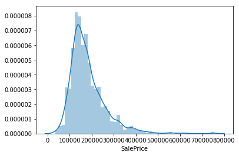

```python
sns.distplot(df['SalePrice'])
```

# Answer 4.2

The histrogram isn't a Normal Distribution, It has very skewness

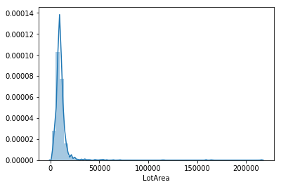

```python
sns.distplot(df['LotArea'])
```

# Answer 4.3

The plot after take log in each axises are better because its remove the skewness of data so the new data are normal distribution

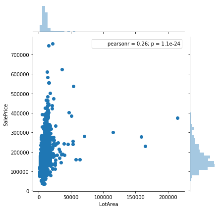

```python
#plot before take log
sns.jointplot(x = "LotArea", y = "SalePrice", data=df)
```

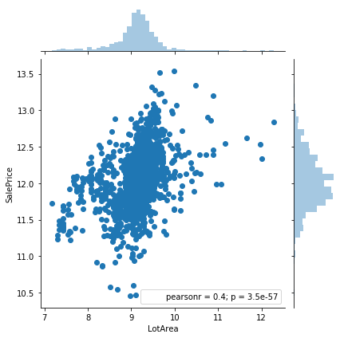

```python
#plot after take log
cpdf = df.copy() # copy dataframe then take log at two column
cpdf['SalePrice'] = np.log(df['SalePrice'])
cpdf['LotArea'] = np.log(df['LotArea'])

sns.jointplot(x = "LotArea", y = "SalePrice", data=cpdf) #plot new dataframe
```

## 5. Dealing with missing values

1. Suppose we want to start the first step of house price modeling by exploring the relationship between four variables: MSSubClass, LotArea, LotFrontage and SalePrice. I have done some exploring and found out that LotFrontage has a lot of missing values, so you need to fix it.
2. LotFrontage is the width of the front side of the property. Use Pandas to find out how many of the houses in our database is missing LotFrontage value.
3. Use Pandas to replace NaN values with another number. Since we are just exploring and not modeling yet, you can simply replace NaN with zeros for now.

# Answer 5

1. It has 259 missing values
2. use df[np.isnan(df['LotFrontage'])] = 0 to replace NaN by zero

```python
print(len(df[np.isnan(df['LotFrontage'])])) #How many NaN in 'LotFrontage'
```

```
259
```

```python
df[np.isnan(df['LotFrontage'])] = 0 #replace NaN by zero
```

```python
df['LotFrontage'].unique() #recheck there aren't NaN in 'LotFrontage'
```

```
array([ 65.,  80.,  68.,  60.,  84.,  85.,  75.,   0.,  51.,  50.,  70.,
        91.,  72.,  66., 101.,  57.,  44., 110.,  98.,  47., 108., 112.,
        74., 115.,  61.,  48.,  33.,  52., 100.,  24.,  89.,  63.,  76.,
        81.,  95.,  69.,  21.,  32.,  78., 121., 122.,  40., 105.,  73.,
        77.,  64.,  94.,  34.,  90.,  55.,  88.,  82.,  71., 120., 107.,
        92., 134.,  62.,  86., 141.,  97.,  54.,  41.,  79., 174.,  99.,
        67.,  83.,  43., 103.,  93.,  30., 129., 140.,  35.,  37., 118.,
        87., 116., 150., 111.,  49.,  96.,  59.,  36.,  56., 102.,  58.,
        38., 109., 130.,  53., 137.,  45., 106., 104.,  42.,  39., 144.,
       114., 128., 149., 313., 168., 182., 138., 160., 152., 124., 153.,
        46.])
```

## 6. Correlations between multiple variables

One incredible feature of Seaborn is the ability to create correlation grid with pairplot function. We want to create one single plot that show us how all variables are correlated.

1. First, you need to create a data table with four columns: MSSubClass, LotArea (with log function applied), LotFrontage (missing values replaced) and SalePrice (with log function applied).
2. Then, use pairplot to create a grid of correlation plots. What do you observe from this plot?

# Answer 6

1. Create new Dataframe the assign data in each columns
2. The plot show that in each subclass has many saleprice and the saleprice relative with LotArea and LotFrontage, I found at subclass = 0 the LotFrontage = 0 Too.

```python
#create new data frame
ndf = pd.DataFrame(columns = ['MSSubClass','LotArea','LotFrontage','SalePrice'])
ndf['MSSubClass'] = df['MSSubClass']
ndf['LotArea'] = cpdf['LotArea'] #log function applied
ndf['LotFrontage'] = df['LotFrontage']
ndf['SalePrice'] = cpdf['SalePrice'] #log function applied
```

```python
ndf.head() #Check data frame collect
```

|  | MSSubClass | LotArea | LotFrontage | SalePrice |
| --- | --- | --- | --- | --- |
| 0 | 60 | 9.041922 | 65.0 | 12.247694 |
| 1 | 20 | 9.169518 | 80.0 | 12.109011 |
| 2 | 60 | 9.328123 | 68.0 | 12.317167 |
| 3 | 70 | 9.164296 | 60.0 | 11.849398 |
| 4 | 60 | 9.565214 | 84.0 | 12.429216 |

```python
np.shape(ndf) #Check new data frame still has 1460 rows
```

```
(1460, 4)
```

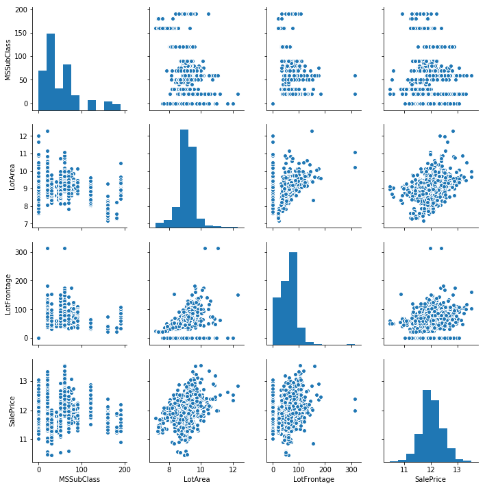

```python
sns.pairplot(ndf)
```

## 7. Data Preparation

Let's prepare train.csv for model training

1. Pick columns that are numeric data and plot distributions of those data (with Seaborn). If you find a column with skewed distribution you will write a script to transform that column with a log function. Then standardize them.
2. For categorical variables, we will simply transform categorical data into numeric data by using function `pandas.get dummies()`.
3. Split data into x and y. The variable x contains all the house features except the SalePrice. y contains only the SalePrice.

# Answer 7

1. Create new dataframe to collect numeric data, remove numeric that be categorical data, fill nan value by mean of that column
2. Remove skewness by np.log but add 1 in skewed column for resolve -inf value after take log(0)
3. Standardize by using Z-Score
4. Create new dataframe to collect categorical data the one-hot encoding by using pd.get_dummies
5. Concatenate numeric data and categorical data in new dataframe
6. split to x and y

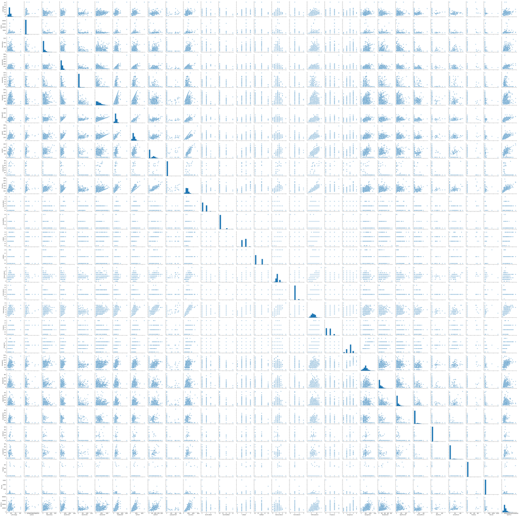

```python
df = pd.read_csv(Location) #read data
# choose numerical data
numerical_df = df.select_dtypes(include=['number','integer','floating'])
# categorical data with numerical data type
cat_numeric = ['Id','MSSubClass', 'OverallQual', 'OverallCond','YearBuilt', 'YearRemodAdd', 'GarageYrBlt', 'MoSold', 'YrSold']
# drop categorical data
for i in cat_numeric:
    numerical_df = numerical_df.drop(columns = i)
# fill NaN Value by mean
numerical_df = numerical_df.fillna(numerical_df.mean())
sns.pairplot(numerical_df) # plot to see distribution
```

```python
#Remove skewness
skew_numerical_df = numerical_df.copy() #new data frame for after remove skewed
for i in numerical_df:
    skewness = numerical_df[i].skew()
    if abs(skewness) >= 1: #skewed distribution if abs(skewness) >= 1
        skew_numerical_df[i] = np.log(numerical_df[i]+1)
```

```python
#Standardize by using z-score
skew_numerical_df = (skew_numerical_df-skew_numerical_df.mean())/skew_numerical_df.std()
```

```python
#one-hot encoding categorical data
cate_df = df.select_dtypes(exclude=['number','integer','floating'])
cate_df = pd.get_dummies(cate_df)
```

```python
cate_num_df = pd.DataFrame() #new data frame for categorical numerical type
for i in cat_numeric:
    if i != 'Id': #except 'Id'
        x = pd.get_dummies(df[i]) # one-hot encoding in each columns
        cate_num_df = pd.concat([cate_num_df,x],axis = 1) #concatenate to data frame in next column
```

```python
# Final data frame for already preprocessing data
prepare_df = pd.concat([skew_numerical_df,cate_num_df,cate_df],axis = 1)
prepare_df.head()
```

|  | LotFrontage | LotArea | MasVnrArea | BsmtFinSF1 | BsmtFinSF2 | BsmtUnfSF | TotalBsmtSF | 1stFlrSF | 2ndFlrSF | LowQualFinSF | ... | SaleType_ConLw | SaleType_New | SaleType_Oth | SaleType_WD | SaleCondition_Abnorml | SaleCondition_AdjLand | SaleCondition_Alloca | SaleCondition_Family | SaleCondition_Normal | SaleCondition_Partial |
| --- | --- | --- | --- | --- | --- | --- | --- | --- | --- | --- | --- | --- | --- | --- | --- | --- | --- | --- | --- | --- | --- |
| 0 | -0.087176 | -0.133225 | 1.192665 | 0.779164 | -0.355221 | -0.944267 | 0.002512 | -0.803370 | 1.161454 | -0.133557 | ... | 0 | 0 | 0 | 1 | 0 | 0 | 0 | 0 | 1 | 0 |
| 1 | 0.563517 | 0.113374 | -0.815680 | 0.887953 | -0.355221 | -0.641008 | 0.340998 | 0.418335 | -0.794891 | -0.133557 | ... | 0 | 0 | 0 | 1 | 0 | 0 | 0 | 0 | 1 | 0 |
| 2 | 0.054061 | 0.419905 | 1.120646 | 0.654579 | -0.355221 | -0.301540 | 0.065374 | -0.576479 | 1.188943 | -0.133557 | ... | 0 | 0 | 0 | 1 | 0 | 0 | 0 | 0 | 1 | 0 |
| 3 | -0.337486 | 0.103282 | -0.815680 | 0.384407 | -0.355221 | -0.061648 | -0.105783 | -0.439270 | 0.936955 | -0.133557 | ... | 0 | 0 | 0 | 1 | 1 | 0 | 0 | 0 | 0 | 0 |
| 4 | 0.716670 | 0.878130 | 1.412226 | 0.754141 | -0.355221 | -0.174805 | 0.256149 | 0.112089 | 1.617323 | -0.133557 | ... | 0 | 0 | 0 | 1 | 0 | 0 | 0 | 0 | 1 | 0 |

5 rows × 602 columns

```python
# y collected SalePrice
y = prepare_df.loc[:,['SalePrice']]

# x collected all except 'SalePrice'
x = prepare_df.loc[:,:]
x = x.drop(columns = 'SalePrice')
```

## 8. Let us first fit a very simple linear regression model, just to see what we get.

1. Use import LinearRegression from sklearn.linear model and use function `fit()` to fit the model.
2. Use function `predict()` to get house price predictions from the model (let’s call the predicted house prices yhat).
3. Plot `y` against `yhat` to see how good your predictions are.

# Answer 8

กราฟที่ได้จากการ plot ดูแล้วมีแนวโน้มเป็นเส้นตรง แสดงว่าการ model predict ได้ค่อนข้างดี

```
Text(0.5,0,'y')
```

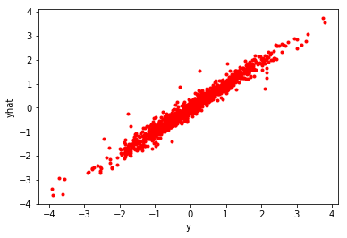

```python
regr = linear_model.LinearRegression() # create regresion model
regr.fit(x,y) #fit model
yhat = regr.predict(x) #use regression model to predict
# plot y againt
plt.plot(y,yhat,'r.')
plt.ylabel('yhat')
plt.xlabel('y')
```

## 9. Assessing Your Model

According to Kaggle’s official rule on this problem, they use root mean square errors (rmse) to judge the accuracy of our model. This error computes the dif- ference between the log of actual house prices and the log of predicted house price. Find the mean and squareroot them.

We want to see how we compare to other machine learning contestants on Kag- gle so let us compute our rmse. Luckily, sklearn has done most of the work for you by providing mean square error function. You can use it by importing the function from sklearn.metrics. Then, you can compute mean square error and take a squareroot to get rmse.

What’s the rmse of your current model? Check out Kaggle Leaderboard for this problem to see how your number measures up with the other contestants.

# Answer 9

the root means square error is 0.195627

```python
rms = np.sqrt(np.square(y-yhat).mean())
print(rms)
```

```
SalePrice    0.195627
dtype: float64
```

## 10. Cross Validation

As we discussed earlier, don’t brag about your model’s accuracy until you have performed cross validation. Let us check cross-validated performance to avoid embarrassment.

Luckily, scikit learn has done most of the work for us once again. You can use the function `cross_val_predict()` to train the model with cross validation method and output the predictions.

What’s the rmse of your cross-validated model? Discuss what you observe in your results here. You may try plotting this new yhat with y to get better insights about this question.

# Answer10

จากกราฟที่ได้ พบว่า model predict ได้แย่มากถ้าใช้ cross validation method เมื่อเทียบกับ predict แบบธรรมดา โดย rms อันใหม่มีค่าเท่ากับ 2.590273e+09 หมายความว่า model predict error เยอะมาก

```python
cross_val_y = cross_val_predict(regr,x,y)
```

```python
rms_cross = np.sqrt(np.square(y-cross_val_y).mean())
rms_cross
```

```
SalePrice    2.590273e+09
dtype: float64
```

```
Text(0.5,0,'y')
```

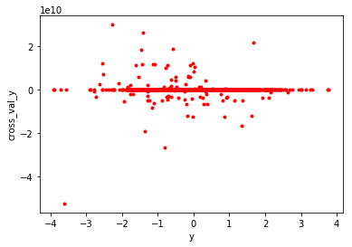

```python
plt.plot(y,cross_val_y,'r.')
plt.ylabel('cross_val_y')
plt.xlabel('y')
```

## 11 (Optional) Fit Better Models

There are other models you can fit that will perform better than linear regres- sion. For example, you can fit linear regression with L2 regularization. This class of models has a street name of ‘Ridge Regression’ and sklearn simply called them Ridge. As we learned last time, this model will fight overfitting problem. Furthermore, you can try linear regression with L1 regularization (street name Lasso Regression or Lasso in sklearn). Try these models and see how you com- pare with other Kagglers now. You can write about your findings below.

```python
# create Lasso and Ridge regression model
lsso = linear_model.Lasso()
ridge = linear_model.Ridge()

#fit model
lsso.fit(x,y)
ridge.fit(x,y)
```

```
Ridge(alpha=1.0, copy_X=True, fit_intercept=True, max_iter=None,
   normalize=False, random_state=None, solver='auto', tol=0.001)
```

```python
#predict data
lsso_y = lsso.predict(x)
ridge_y = ridge.predict(x)
```

```python
lsso_y = np.reshape(lsso_y,(1460,1)) #shape of lsso_y is (1460,) So I reshape it to (1460,1)
```

```python
#calculate root mean square error
rms_lsso = np.sqrt(np.square(y-lsso_y).mean())
rms_ridge = np.sqrt(np.square(y-ridge_y).mean())
print(rms_lsso)
print(rms_ridge)
```

```
SalePrice    0.999657
dtype: float64
SalePrice    0.212888
dtype: float64
```